# Tooth Growth in Guinea Pigs

Kunal Kumar

# Overview

This analysis is part of a project for the course “Statistical Inference” offered by Johns Hopkins University on Coursera. We will investigate the “ToothGrowth” dataset which is part of the R datasets package. The aim is to check if any variables can be causally linked with increase in length of odontoblasts in guinea pigs. Odontoblasts are cells found in the crown of teeth, just below the enamel, and aid in tooth growth.

Note : The description of the dataset (in R version 3.2.2 or earlier) is wrong, as pointed out [here](https://bugs.r-project.org/bugzilla3/show_bug.cgi?id=15953).

Let us begin by loading the dataset as a dataframe.

```r
## Loading relevant data
library(datasets)
tooth <- data.frame(ToothGrowth)
```

## Summary of data

To get a sense of what the data looks like let’s use the str() function.

```r
str(tooth)
```

```
## 'data.frame':    60 obs. of  3 variables:
##  $ len : num  4.2 11.5 7.3 5.8 6.4 10 11.2 11.2 5.2 7 ...
##  $ supp: Factor w/ 2 levels "OJ","VC": 2 2 2 2 2 2 2 2 2 2 ...
##  $ dose: num  0.5 0.5 0.5 0.5 0.5 0.5 0.5 0.5 0.5 0.5 ...
```

The data contains length (in microns) of odontoblasts for different combinations of dose (0.5,1,2mg/day) and delivery method of Vit. C (orange juice (OJ) or Vit. C tablet (VC)). There are 6 combinations of these two variables. For each combination we have data from 10 guinea pigs. In all, 60 distinct pigs received a dose of a supplement containing Vitamin C.

## Exploratory Analysis

Let’s make a preliminary plot in order to spot any obvious patterns.

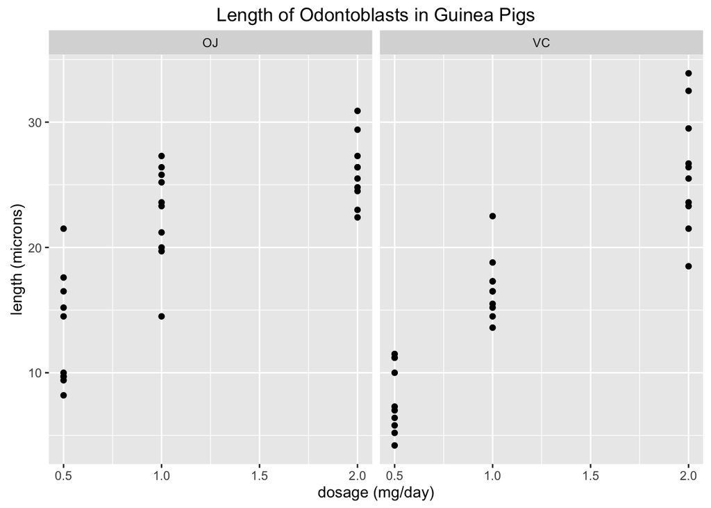

```r
library(ggplot2)
qplot(x = dose, y = len, data = tooth, facets = .~supp, ylab = "length (microns)",
      xlab = "dosage (mg/day)", main = "Length of Odontoblasts in Guinea Pigs")
```

It seems likely that an increase in dosage leads to an increase in length, irrespective of the delivery method. Let’s look at the mean and variance for each of the 6 groups of points.

```r
tapply(tooth$len, list(tooth$supp,tooth$dose), mean)
```

```
##      0.5     1     2
## OJ 13.23 22.70 26.06
## VC  7.98 16.77 26.14
```

```r
tapply(tooth$len, list(tooth$supp,tooth$dose), var)
```

```
##       0.5         1         2
## OJ 19.889 15.295556  7.049333
## VC  7.544  6.326778 23.018222
```

From the table for variance, we note that the variance for 2 mg/d dose is least for the group with delivery method OJ and most for the group with delivery method VC. There isn’t enough information to speculate on why this might be the case.

# Splitting data

In order to aid further analysis, let us split the data into 6 groups based on dosage and delivery method.

```r
## First two letters denote delivery type. "pt5", "1", "2" denote dosage of .5,1 and
## 2 mg/day.
OJpt5 <- subset(tooth, tooth$supp == "OJ" & tooth$dose == 0.5)
OJ1 <- subset(tooth, tooth$supp == "OJ" & tooth$dose == 1)
OJ2 <- subset(tooth, tooth$supp == "OJ" & tooth$dose == 2)

VCpt5 <- subset(tooth, tooth$supp == "VC" & tooth$dose == 0.5)
VC1 <- subset(tooth, tooth$supp == "VC" & tooth$dose == 1)
VC2 <- subset(tooth, tooth$supp == "VC" & tooth$dose == 2)
```

# Effect of increase in dosage

We can perform two sided t-tests to determine if increased dosage actually leads to an increase in length. Note that this means we are assuming the underlying distributions are gaussian. We will use 95% C.L. intervals. Let us compare 0.5 vs 1 mg/day for the delivery method “OJ”. The two groups are independent and we will assume their population variances are different.

```r
t.test(OJpt5$len, OJ1$len, conf.level = .95)
```

```
##
##  Welch Two Sample t-test
##
## data:  OJpt5$len and OJ1$len
## t = -5.0486, df = 17.698, p-value = 8.785e-05
## alternative hypothesis: true difference in means is not equal to 0
## 95 percent confidence interval:
##  -13.415634  -5.524366
## sample estimates:
## mean of x mean of y
##     13.23     22.70
```

Since the t-statistic is -5.0486 and the 95% CL interval (-13.42, -5.52) microns (for the difference in lengths) does not include 0 microns, we can conclude that increase in dosage leads to increase in length of odontoblasts. Let us look at the 95% confidence interval for 1mg/day vs 2 mg/day.

```r
t.test(OJ1$len, OJ2$len, conf.level = .95)$conf[1:2]
```

```
## [1] -6.5314425 -0.1885575
```

Let’s repeat the above t-tests (at 95% CL) for the delivery method of Vit. C tablets (VC).

```r
t.test(VCpt5$len, VC1$len, conf.level = .95)$conf[1:2]
```

```
## [1] -11.265712  -6.314288
```

```r
t.test(VC1$len, VC2$len, conf.level = .95)$conf[1:2]
```

```
## [1] -13.054267  -5.685733
```

We see again that we can conclude that increase in dosage leads to increase in odontoblast length.

# Effect of delivery method

We can also compare the two different delivery methods keeping dosage fixed.

```r
t.test(OJpt5$len, VCpt5$len, conf.level = .95)$conf[1:2]
```

```
## [1] 1.719057 8.780943
```

```r
t.test(OJ1$len, VC1$len, conf.level = .95)$conf[1:2]
```

```
## [1] 2.802148 9.057852
```

```r
t.test(OJ2$len, VC2$len, conf.level = .95)$conf[1:2]
```

```
## [1] -3.79807  3.63807
```

From the above intervals we can conclude that at doses of 0.5 and 1 mg/day orange juice is a more effective delivery method for increasing length of odontoblasts. At 2 mg/day both delivery methods are equally effective.

# Conclusion

Using 95%CL t-test intervals we conclude that increase in dosage leads to increase in length of odontoblasts for both delivery methods. When comparing the two delivery methods, for equal dosage we find that orange juice is more effective for at .5 and 1 mg/day, while the methods are equally effective at 2mg/day.